# Homework 4: Data Analysis for Problems 2–5

*Kenneth Luna*

**NOTE:** In this assignment, we will use the “forecast” package for R, which adds capabilities for identifying and fitting ARIMA models. You need to install this package before you can complete the assignment.

To install the package choose “Install Packages…” from the “Tools” menu in RStudio. Type `forecast` into the packages field, and make sure the “Install dependencies” box is checked. This will download and install the package.

After you have installed the package, use the following line to load it into R:

```r
library("forecast")
```

If you get an error about a missing library (possibly `quadprog`), then you will need to install the missing library using “Tools > Install Packages…”

# Problem 2

## Housing Starts

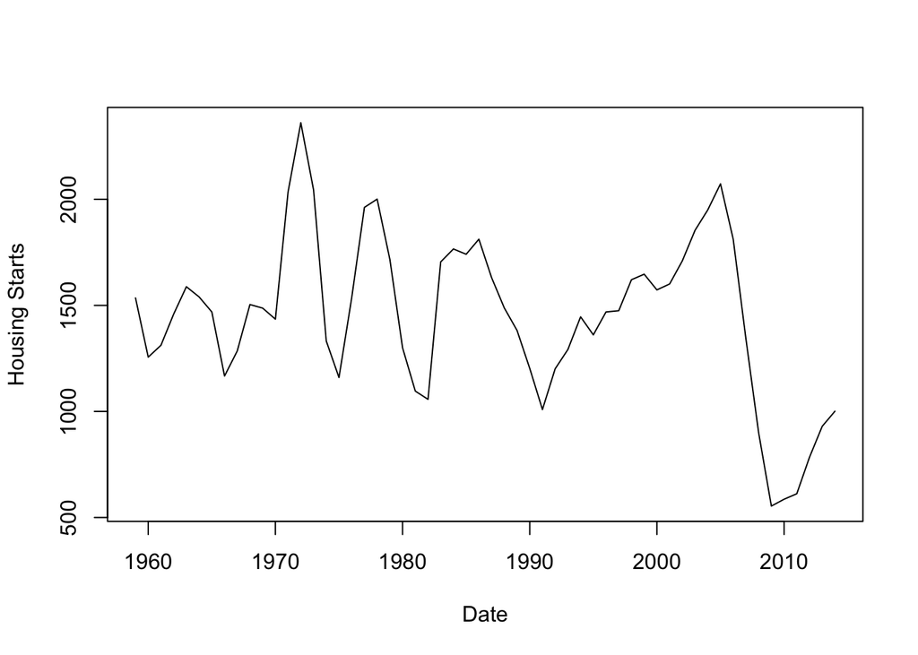

```r
# Read in data:
#   New Privately Owned Housing Units Started (in thousands, for U.S.), Yearly,
#   1959 - Present.
#   Seasonally adjusted annual rate.
#
#   Source: https://research.stlouisfed.org/fred2/series/HOUST/downloaddata
#
hs.data <- read.csv("http://ptrckprry.com/course/forecasting/data/housingstarts.csv")
housing.starts <- hs.data$housing.starts

# Time series plot
par(mfrow=c(1,1))
plot(as.Date(hs.data$date), housing.starts, type="l",
     xlab="Date", ylab="Housing Starts")
```

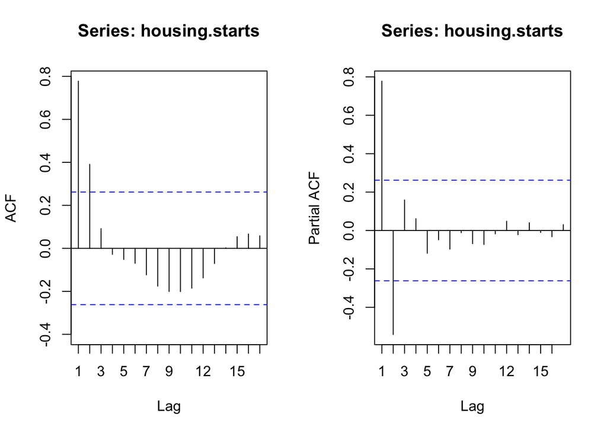

```r
# ACF and PACF
par(mfrow=c(1,2))
Acf(housing.starts)
Pacf(housing.starts)
```

**Identify an ARIMA(p, d, q) model. Give reasons for your choices of p, d, q.**

I would identify this model as ARIMA(0, 0, 2).

16. is zero because the correlagram for an AR(P) would expect a steady decline in the correlogram and that is not the case in this example.
17. is zero because we did not implement any differencing.
18. is 2 as the correlogram cuts off immediately at q = 2. For all k > q, values are close to 0.

## Log GDP

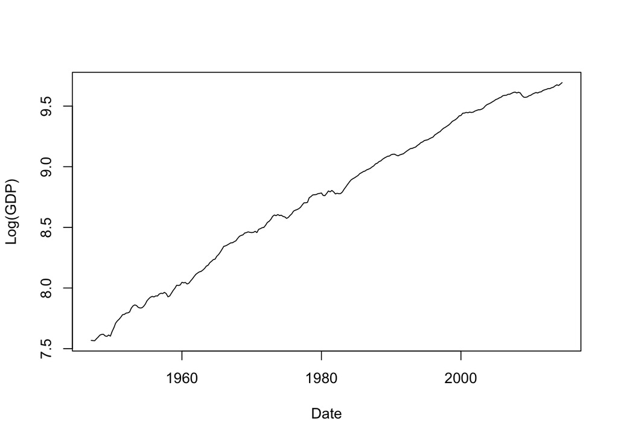

```r
# Read in data:
#   Real United States Gross Domestic Product,
#   1947 (Q1) - Present.
#   Seasonally adjusted and inflation adjusted, in billions of 2009 dollars.
#
#   Source: http://bea.gov/national/
#
gdp.data <- read.csv("http://ptrckprry.com/course/forecasting/data/gdp.csv")
gdp <- gdp.data$gdp

log.gdp <- log(gdp)

# Time series plot
par(mfrow=c(1,1))
plot(as.Date(gdp.data$date), log.gdp, type="l",
     xlab="Date", ylab="Log(GDP)")
```

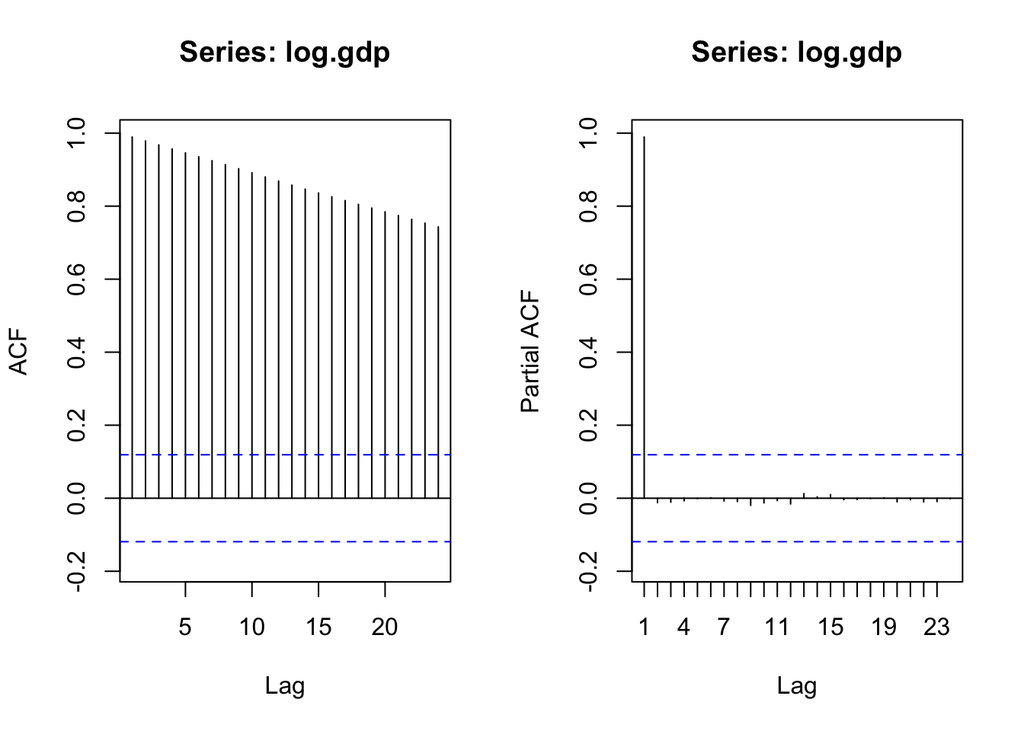

```r
# ACF and PACF
par(mfrow=c(1,2))
Acf(log.gdp)
Pacf(log.gdp)
```

**Identify p, d, q. Give reasons for your choices.**

I would identify this model as ARIMA(1, 0, 0).

16. is 1 because the partial correlogram immediately cuts off at p > 1, there indicating that this has characters of an AR(1) model.
17. is zero because we did not implement any differencing.
18. is 0 as the autocorrelation correlogram gradual decreases over time.

## Diff Log GDP

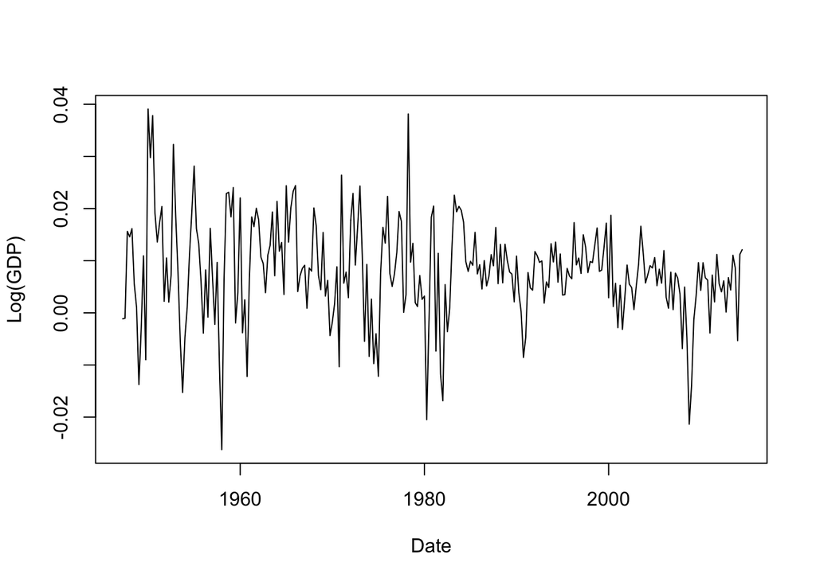

```r
# Take first differences
diff.log.gdp <- c(NA, diff(log.gdp))

# Time series plot
par(mfrow=c(1,1))
plot(as.Date(gdp.data$date), diff.log.gdp, type="l",
     xlab="Date", ylab="Log(GDP)")
```

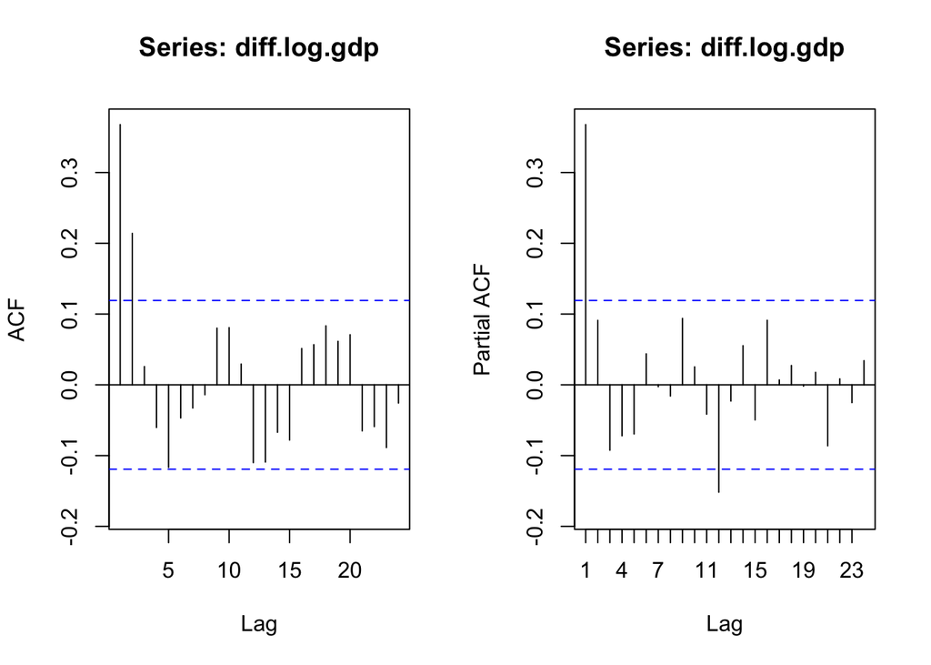

```r
# ACF and PACF
par(mfrow=c(1,2))
Acf(diff.log.gdp)
Pacf(diff.log.gdp)
```

**Identify p, d, q. Give reasons for your choices.**

I would identify this model as ARIMA(1, 1, 0).

16. is 1 as the partial correlogram cuts off after p > 1.
17. is 1 as we took the different from time t and time t-1
18. is 0. The PCF model does not die down as an MA(Q) should, therefore we conclude that the value of q is 0.

## Diff Log CPI (Inflation)

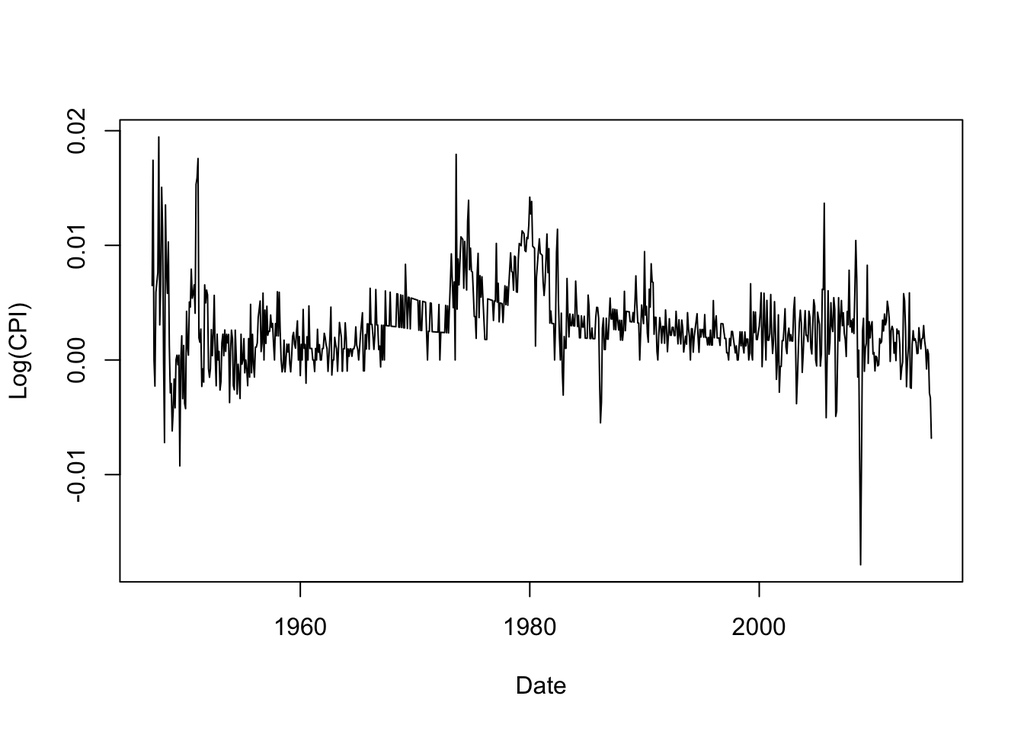

```r
# Read in data:
#  U.S. Consumer Price Index, Monthly,
#  December, 1946 - Present.
#  Seasonally Adjusted. All Urban Consumers (1982 to 1984 as 100).
#
#  Source: https://research.stlouisfed.org/fred2/series/CPIAUCSL/downloaddata
#
cpi.data <- read.csv("http://ptrckprry.com/course/forecasting/data/cpi.csv")
cpi <- cpi.data$cpi

# Take logs
log.cpi = log(cpi)

# Take first differences
diff.log.cpi <- c(NA, diff(log.cpi))

# Time series plot
par(mfrow=c(1,1))
plot(as.Date(cpi.data$date), diff.log.cpi, type="l",
     xlab="Date", ylab="Log(CPI)")
```

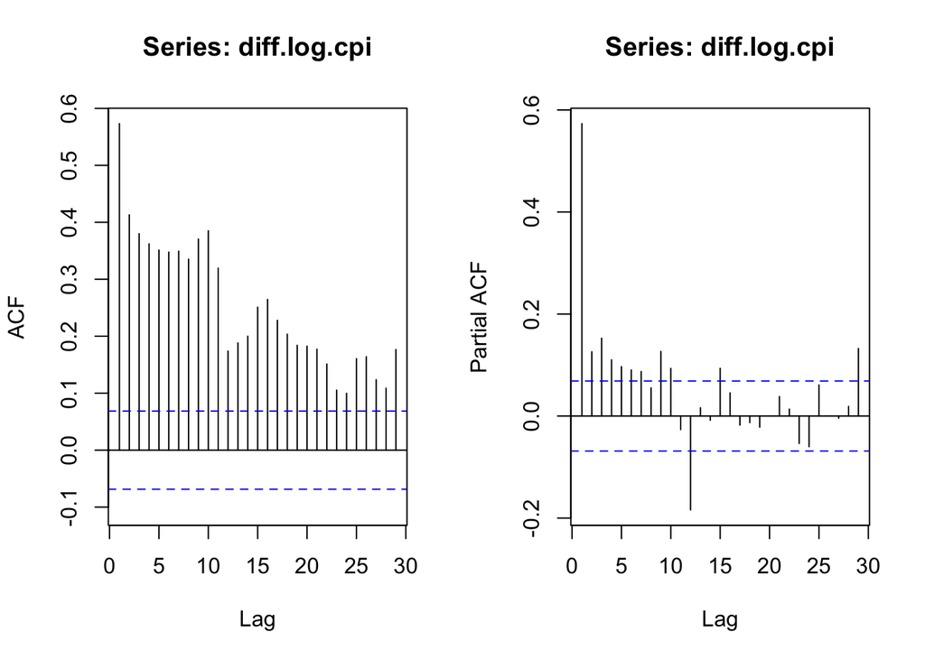

```r
# ACF and PACF
par(mfrow=c(1,2))
Acf(diff.log.cpi)
Pacf(diff.log.cpi)
```

**Identify p, d, q. Give reasons for your choices.**

I would identify this model as ARIMA(1,1,1).

16. is 1 as the diff.log.cpi gradually dies down.
17. is 1 as the difference was taken once.
18. is 1 as the diff.log.cpi gradually dies down as well.

**For the inflation series (first log of the CPI) determine if additional differencing results in over-differencing.**

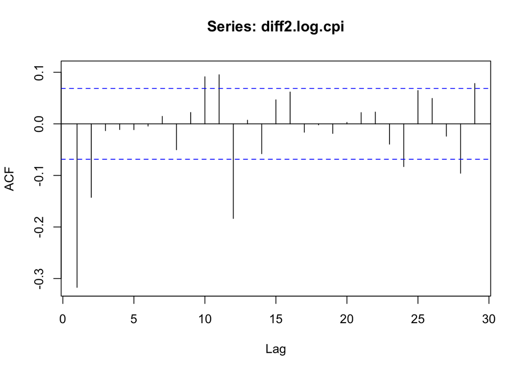

```r
# Take differences of inflation (second differences of log CPI)
diff2.log.cpi <- c(NA, diff(diff.log.cpi))

# Compute ACF
par(mfrow=c(1,1))
Acf(diff2.log.cpi)
```

```r
# Use this plot to determine if additional differencing results in over-differencing.
```

# Problems 3–5

To complete Problems 3–5, we need to compute the sample autocorrelations for the first difference of the log GDP series.

```r
# Hint: use the Acf funciton with plot=FALSE to get the estimated autocorrelations
Acf(diff.log.gdp, plot = FALSE)
```

```
##
## Autocorrelations of series 'diff.log.gdp', by lag
##
##      0      1      2      3      4      5      6      7      8      9
##  1.000  0.368  0.214  0.026 -0.060 -0.117 -0.047 -0.033 -0.014  0.080
##     10     11     12     13     14     15     16     17     18     19
##  0.081  0.029 -0.110 -0.109 -0.067 -0.078  0.051  0.057  0.083  0.061
##     20     21     22     23     24
##  0.071 -0.065 -0.059 -0.089 -0.026
```

**Use the estimated autocorrelations to complete Problems 3–5. Show your work on a separate page.**

For Problem 5(c), we need the last few values of `diff.log.gdp` and `log.gdp`. We can get these with the `tail` command:

```r
# Uncomment the following lines to get the last 5 values of log.gdp and diff.log.gdp:
tail(log.gdp)
```

```
## [1] 9.655449 9.666492 9.675093 9.669770 9.680994 9.693112
```

```r
tail(diff.log.gdp)
```

```
## [1]  0.004379522  0.011043077  0.008600480 -0.005323199  0.011224252
## [6]  0.012118350
```

Notes for 5(c)

```r
tail(diff.log.gdp)[6] # t -1
```

```
## [1] 0.01211835
```

```r
tail(diff.log.gdp)[5] # t -2
```

```
## [1] 0.01122425
```

```r
xt <- -.254 * tail(diff.log.gdp)[6] + .307 * tail(diff.log.gdp)[5]
```